# Optimal Treatment Analysis

## Outcome Variable

**Outcome Variable:** haz

## Predictor Variables

**Intervention Variable:** mwtkg

**Adjustment Set:**

- arm
- W_mage
- W_fage
- meducyrs
- feducyrs
- single
- brthmon
- delta_W_mage
- delta_W_fage
- delta_meducyrs
- delta_feducyrs
- delta_single
- delta_brthmon

## Stratifying Variables

The analysis was stratified on these variable(s):

- agecat
- studyid
- country

## Data Summary

| agecat | studyid | country | mwtkg | n_cell | n |
| --- | --- | --- | --- | --- | --- |
| Birth | ki0047075b-MAL-ED | BANGLADESH | >=58 kg | 47 | 246 |
| Birth | ki0047075b-MAL-ED | BANGLADESH | <52 kg | 156 | 246 |
| Birth | ki0047075b-MAL-ED | BANGLADESH | [52-58) kg | 43 | 246 |
| Birth | ki0047075b-MAL-ED | BRAZIL | >=58 kg | 121 | 184 |
| Birth | ki0047075b-MAL-ED | BRAZIL | <52 kg | 33 | 184 |
| Birth | ki0047075b-MAL-ED | BRAZIL | [52-58) kg | 30 | 184 |
| Birth | ki0047075b-MAL-ED | INDIA | >=58 kg | 36 | 198 |
| Birth | ki0047075b-MAL-ED | INDIA | <52 kg | 123 | 198 |
| Birth | ki0047075b-MAL-ED | INDIA | [52-58) kg | 39 | 198 |
| Birth | ki0047075b-MAL-ED | NEPAL | >=58 kg | 57 | 172 |
| Birth | ki0047075b-MAL-ED | NEPAL | <52 kg | 52 | 172 |
| Birth | ki0047075b-MAL-ED | NEPAL | [52-58) kg | 63 | 172 |
| Birth | ki0047075b-MAL-ED | PERU | >=58 kg | 99 | 276 |
| Birth | ki0047075b-MAL-ED | PERU | <52 kg | 107 | 276 |
| Birth | ki0047075b-MAL-ED | PERU | [52-58) kg | 70 | 276 |
| Birth | ki0047075b-MAL-ED | SOUTH AFRICA | >=58 kg | 166 | 228 |
| Birth | ki0047075b-MAL-ED | SOUTH AFRICA | <52 kg | 23 | 228 |
| Birth | ki0047075b-MAL-ED | SOUTH AFRICA | [52-58) kg | 39 | 228 |
| Birth | ki0047075b-MAL-ED | TANZANIA, UNITED REPUBLIC OF | >=58 kg | 52 | 121 |
| Birth | ki0047075b-MAL-ED | TANZANIA, UNITED REPUBLIC OF | <52 kg | 40 | 121 |
| Birth | ki0047075b-MAL-ED | TANZANIA, UNITED REPUBLIC OF | [52-58) kg | 29 | 121 |
| Birth | ki1000304b-SAS-CompFeed | INDIA | >=58 kg | 14 | 182 |
| Birth | ki1000304b-SAS-CompFeed | INDIA | <52 kg | 141 | 182 |
| Birth | ki1000304b-SAS-CompFeed | INDIA | [52-58) kg | 27 | 182 |
| Birth | ki1017093-NIH-Birth | BANGLADESH | >=58 kg | 2 | 28 |
| Birth | ki1017093-NIH-Birth | BANGLADESH | <52 kg | 23 | 28 |
| Birth | ki1017093-NIH-Birth | BANGLADESH | [52-58) kg | 3 | 28 |
| Birth | ki1017093c-NIH-Crypto | BANGLADESH | >=58 kg | 4 | 27 |
| Birth | ki1017093c-NIH-Crypto | BANGLADESH | <52 kg | 20 | 27 |
| Birth | ki1017093c-NIH-Crypto | BANGLADESH | [52-58) kg | 3 | 27 |

[output cut: 93 more lines]

The following strata were considered:

- agecat: 24 months, studyid: ki0047075b-MAL-ED, country: BANGLADESH
- agecat: 24 months, studyid: ki0047075b-MAL-ED, country: BRAZIL
- agecat: 24 months, studyid: ki0047075b-MAL-ED, country: INDIA
- agecat: 24 months, studyid: ki0047075b-MAL-ED, country: NEPAL
- agecat: 24 months, studyid: ki0047075b-MAL-ED, country: PERU
- agecat: 24 months, studyid: ki0047075b-MAL-ED, country: SOUTH AFRICA
- agecat: 24 months, studyid: ki0047075b-MAL-ED, country: TANZANIA, UNITED REPUBLIC OF
- agecat: 24 months, studyid: ki1017093-NIH-Birth, country: BANGLADESH
- agecat: 24 months, studyid: ki1017093b-PROVIDE, country: BANGLADESH
- agecat: 24 months, studyid: ki1017093c-NIH-Crypto, country: BANGLADESH
- agecat: 24 months, studyid: ki1066203-TanzaniaChild2, country: TANZANIA, UNITED REPUBLIC OF
- agecat: 24 months, studyid: ki1119695-PROBIT, country: BELARUS
- agecat: 24 months, studyid: ki1126311-ZVITAMBO, country: ZIMBABWE
- agecat: 24 months, studyid: ki1148112-LCNI-5, country: MALAWI
- agecat: 6 months, studyid: ki0047075b-MAL-ED, country: BANGLADESH
- agecat: 6 months, studyid: ki0047075b-MAL-ED, country: BRAZIL
- agecat: 6 months, studyid: ki0047075b-MAL-ED, country: INDIA
- agecat: 6 months, studyid: ki0047075b-MAL-ED, country: NEPAL
- agecat: 6 months, studyid: ki0047075b-MAL-ED, country: PERU
- agecat: 6 months, studyid: ki0047075b-MAL-ED, country: SOUTH AFRICA
- agecat: 6 months, studyid: ki0047075b-MAL-ED, country: TANZANIA, UNITED REPUBLIC OF
- agecat: 6 months, studyid: ki1000304b-SAS-CompFeed, country: INDIA
- agecat: 6 months, studyid: ki1017093-NIH-Birth, country: BANGLADESH
- agecat: 6 months, studyid: ki1017093b-PROVIDE, country: BANGLADESH
- agecat: 6 months, studyid: ki1017093c-NIH-Crypto, country: BANGLADESH
- agecat: 6 months, studyid: ki1066203-TanzaniaChild2, country: TANZANIA, UNITED REPUBLIC OF
- agecat: 6 months, studyid: ki1119695-PROBIT, country: BELARUS
- agecat: 6 months, studyid: ki1126311-ZVITAMBO, country: ZIMBABWE
- agecat: 6 months, studyid: ki1148112-LCNI-5, country: MALAWI
- agecat: Birth, studyid: ki0047075b-MAL-ED, country: BANGLADESH
- agecat: Birth, studyid: ki0047075b-MAL-ED, country: BRAZIL
- agecat: Birth, studyid: ki0047075b-MAL-ED, country: INDIA
- agecat: Birth, studyid: ki0047075b-MAL-ED, country: NEPAL
- agecat: Birth, studyid: ki0047075b-MAL-ED, country: PERU
- agecat: Birth, studyid: ki0047075b-MAL-ED, country: SOUTH AFRICA
- agecat: Birth, studyid: ki0047075b-MAL-ED, country: TANZANIA, UNITED REPUBLIC OF
- agecat: Birth, studyid: ki1000304b-SAS-CompFeed, country: INDIA
- agecat: Birth, studyid: ki1017093-NIH-Birth, country: BANGLADESH
- agecat: Birth, studyid: ki1017093c-NIH-Crypto, country: BANGLADESH
- agecat: Birth, studyid: ki1119695-PROBIT, country: BELARUS
- agecat: Birth, studyid: ki1126311-ZVITAMBO, country: ZIMBABWE

### Dropped Strata

Some strata were dropped due to rare outcomes:

- agecat: Birth, studyid: ki1017093-NIH-Birth, country: BANGLADESH
- agecat: Birth, studyid: ki1017093c-NIH-Crypto, country: BANGLADESH
- agecat: 24 months, studyid: ki1066203-TanzaniaChild2, country: TANZANIA, UNITED REPUBLIC OF

## Methods Detail

We’re interested in the causal parameters $E[Y_a]$ for all values of $a \in \mathcal{A}$. These parameters represent the mean outcome if, possibly contrary to fact, we intervened to set all units to have $A=a$. Under the randomization and positivity assumptions, these are identified by the statistical parameters $\psi_a=E_W[E_{Y|A,W}(Y|A=a,W)]$. In addition, we’re interested in the mean of $Y$, $E[Y]$ under no intervention (the observed mean). We will estimate these parameters by using SuperLearner to fit the relevant likelihood factors – $E_{Y|A,W}(Y|A=a,W)$ and $p(A=a|W)$, and then updating our likelihood fit using a joint TMLE.

For unadjusted analyses ($W=\{\}$), initial likelihoods were estimated using Lrnr_glm to estimate the simple $E(Y|A)$ and Lrnr_mean to estimate $p(A)$. For adjusted analyses, a small library containing Lrnr_glmnet, Lrnr_xgboost, and Lrnr_mean was used.

Having estimated these parameters, we will then use the delta method to estimate relative risks and attributable risks relative to a prespecified baseline level of $A$.

# Results Detail

## Results Plots

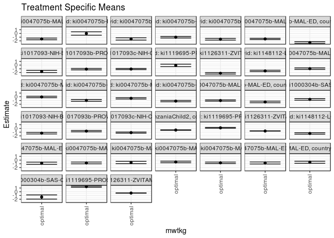

## Results Table

### Parameter: TSM

| agecat | studyid | country | intervention_level | baseline_level | estimate | ci_lower | ci_upper |
| --- | --- | --- | --- | --- | --- | --- | --- |
| Birth | ki0047075b-MAL-ED | BANGLADESH | optimal | observed | -0.8415023 | -1.1389967 | -0.5440079 |
| Birth | ki0047075b-MAL-ED | BRAZIL | optimal | observed | -0.7633298 | -1.0092345 | -0.5174252 |
| Birth | ki0047075b-MAL-ED | INDIA | optimal | observed | -0.6508983 | -0.9684939 | -0.3333026 |
| Birth | ki0047075b-MAL-ED | NEPAL | optimal | observed | -0.5043092 | -0.7202442 | -0.2883741 |
| Birth | ki0047075b-MAL-ED | PERU | optimal | observed | -0.7297045 | -0.9307065 | -0.5287025 |
| Birth | ki0047075b-MAL-ED | SOUTH AFRICA | optimal | observed | -0.7728746 | -1.0455315 | -0.5002178 |
| Birth | ki0047075b-MAL-ED | TANZANIA, UNITED REPUBLIC OF | optimal | observed | -0.5803263 | -0.8578451 | -0.3028075 |
| Birth | ki1000304b-SAS-CompFeed | INDIA | optimal | observed | -1.4135097 | -1.9750020 | -0.8520175 |
| Birth | ki1119695-PROBIT | BELARUS | optimal | observed | 1.3809842 | 1.2199662 | 1.5420022 |
| Birth | ki1126311-ZVITAMBO | ZIMBABWE | optimal | observed | -0.3510879 | -0.3827927 | -0.3193830 |
| 6 months | ki0047075b-MAL-ED | BANGLADESH | optimal | observed | -0.9572764 | -1.1642689 | -0.7502839 |
| 6 months | ki0047075b-MAL-ED | BRAZIL | optimal | observed | -0.0499345 | -0.2444153 | 0.1445463 |
| 6 months | ki0047075b-MAL-ED | INDIA | optimal | observed | -0.9826483 | -1.2293727 | -0.7359240 |
| 6 months | ki0047075b-MAL-ED | NEPAL | optimal | observed | -0.4255044 | -0.6027552 | -0.2482536 |
| 6 months | ki0047075b-MAL-ED | PERU | optimal | observed | -1.1621075 | -1.3512538 | -0.9729612 |
| 6 months | ki0047075b-MAL-ED | SOUTH AFRICA | optimal | observed | -1.0134724 | -1.1845556 | -0.8423892 |
| 6 months | ki0047075b-MAL-ED | TANZANIA, UNITED REPUBLIC OF | optimal | observed | -1.4016084 | -1.6181968 | -1.1850201 |
| 6 months | ki1000304b-SAS-CompFeed | INDIA | optimal | observed | -0.7016586 | -0.9277659 | -0.4755512 |
| 6 months | ki1017093-NIH-Birth | BANGLADESH | optimal | observed | -1.2754386 | -1.4935390 | -1.0573383 |
| 6 months | ki1017093b-PROVIDE | BANGLADESH | optimal | observed | -0.7256983 | -0.9056128 | -0.5457838 |
| 6 months | ki1017093c-NIH-Crypto | BANGLADESH | optimal | observed | -1.1252879 | -1.2752813 | -0.9752944 |
| 6 months | ki1066203-TanzaniaChild2 | TANZANIA, UNITED REPUBLIC OF | optimal | observed | -0.4391223 | -0.5030693 | -0.3751753 |
| 6 months | ki1119695-PROBIT | BELARUS | optimal | observed | 0.1618739 | 0.0608886 | 0.2628592 |
| 6 months | ki1126311-ZVITAMBO | ZIMBABWE | optimal | observed | -0.6957079 | -0.7321925 | -0.6592232 |
| 6 months | ki1148112-LCNI-5 | MALAWI | optimal | observed | -1.3550091 | -1.5480445 | -1.1619737 |
| 24 months | ki0047075b-MAL-ED | BANGLADESH | optimal | observed | -1.4749363 | -1.7055323 | -1.2443403 |
| 24 months | ki0047075b-MAL-ED | BRAZIL | optimal | observed | -0.0164814 | -0.4702619 | 0.4372990 |
| 24 months | ki0047075b-MAL-ED | INDIA | optimal | observed | -1.4812954 | -1.7784570 | -1.1841337 |
| 24 months | ki0047075b-MAL-ED | NEPAL | optimal | observed | -1.0176053 | -1.2210229 | -0.8141877 |
| 24 months | ki0047075b-MAL-ED | PERU | optimal | observed | -1.5559314 | -1.7804131 | -1.3314496 |
| 24 months | ki0047075b-MAL-ED | SOUTH AFRICA | optimal | observed | -1.4775307 | -1.6357265 | -1.3193348 |
| 24 months | ki0047075b-MAL-ED | TANZANIA, UNITED REPUBLIC OF | optimal | observed | -2.4613940 | -2.6873412 | -2.2354467 |
| 24 months | ki1017093-NIH-Birth | BANGLADESH | optimal | observed | -1.7110404 | -2.0209356 | -1.4011453 |
| 24 months | ki1017093b-PROVIDE | BANGLADESH | optimal | observed | -1.0875653 | -1.2751256 | -0.9000049 |
| 24 months | ki1017093c-NIH-Crypto | BANGLADESH | optimal | observed | -1.0619855 | -1.2125252 | -0.9114458 |
| 24 months | ki1119695-PROBIT | BELARUS | optimal | observed | -0.0825149 | -0.4170344 | 0.2520047 |
| 24 months | ki1126311-ZVITAMBO | ZIMBABWE | optimal | observed | -2.2076640 | -2.4049335 | -2.0103945 |
| 24 months | ki1148112-LCNI-5 | MALAWI | optimal | observed | -1.5609454 | -1.7518913 | -1.3699995 |

### Parameter: E(Y)

| agecat | studyid | country | intervention_level | baseline_level | estimate | ci_lower | ci_upper |
| --- | --- | --- | --- | --- | --- | --- | --- |
| Birth | ki0047075b-MAL-ED | BANGLADESH | observed | observed | -1.0455285 | -1.1715695 | -0.9194875 |
| Birth | ki0047075b-MAL-ED | BRAZIL | observed | observed | -0.7397283 | -0.8996215 | -0.5798350 |
| Birth | ki0047075b-MAL-ED | INDIA | observed | observed | -1.0200505 | -1.1624932 | -0.8776078 |
| Birth | ki0047075b-MAL-ED | NEPAL | observed | observed | -0.7052907 | -0.8627483 | -0.5478331 |
| Birth | ki0047075b-MAL-ED | PERU | observed | observed | -0.9386232 | -1.0507144 | -0.8265319 |
| Birth | ki0047075b-MAL-ED | SOUTH AFRICA | observed | observed | -0.6921930 | -0.8218578 | -0.5625282 |
| Birth | ki0047075b-MAL-ED | TANZANIA, UNITED REPUBLIC OF | observed | observed | -0.9267769 | -1.1425813 | -0.7109724 |
| Birth | ki1000304b-SAS-CompFeed | INDIA | observed | observed | -1.3716484 | -1.5489439 | -1.1943528 |
| Birth | ki1119695-PROBIT | BELARUS | observed | observed | 1.3264008 | 1.1675653 | 1.4852363 |
| Birth | ki1126311-ZVITAMBO | ZIMBABWE | observed | observed | -0.4974449 | -0.5203958 | -0.4744941 |
| 6 months | ki0047075b-MAL-ED | BANGLADESH | observed | observed | -1.2056777 | -1.3231497 | -1.0882058 |
| 6 months | ki0047075b-MAL-ED | BRAZIL | observed | observed | 0.0532131 | -0.0914567 | 0.1978830 |
| 6 months | ki0047075b-MAL-ED | INDIA | observed | observed | -1.2148369 | -1.3332371 | -1.0964367 |
| 6 months | ki0047075b-MAL-ED | NEPAL | observed | observed | -0.5610593 | -0.6737915 | -0.4483272 |
| 6 months | ki0047075b-MAL-ED | PERU | observed | observed | -1.3272488 | -1.4359649 | -1.2185326 |
| 6 months | ki0047075b-MAL-ED | SOUTH AFRICA | observed | observed | -1.0728012 | -1.2026830 | -0.9429194 |
| 6 months | ki0047075b-MAL-ED | TANZANIA, UNITED REPUBLIC OF | observed | observed | -1.3601215 | -1.4821830 | -1.2380600 |
| 6 months | ki1000304b-SAS-CompFeed | INDIA | observed | observed | -1.4006917 | -1.4821813 | -1.3192022 |
| 6 months | ki1017093-NIH-Birth | BANGLADESH | observed | observed | -1.4073821 | -1.4960598 | -1.3187043 |
| 6 months | ki1017093b-PROVIDE | BANGLADESH | observed | observed | -1.0848568 | -1.1613109 | -1.0084028 |
| 6 months | ki1017093c-NIH-Crypto | BANGLADESH | observed | observed | -1.1986783 | -1.2700937 | -1.1272630 |
| 6 months | ki1066203-TanzaniaChild2 | TANZANIA, UNITED REPUBLIC OF | observed | observed | -0.5424765 | -0.5918460 | -0.4931071 |
| 6 months | ki1119695-PROBIT | BELARUS | observed | observed | 0.1143882 | 0.0212298 | 0.2075466 |
| 6 months | ki1126311-ZVITAMBO | ZIMBABWE | observed | observed | -0.8994195 | -0.9257684 | -0.8730707 |
| 6 months | ki1148112-LCNI-5 | MALAWI | observed | observed | -1.6584707 | -1.7281551 | -1.5887863 |
| 24 months | ki0047075b-MAL-ED | BANGLADESH | observed | observed | -1.9431132 | -2.0691678 | -1.8170586 |
| 24 months | ki0047075b-MAL-ED | BRAZIL | observed | observed | 0.0418452 | -0.1263708 | 0.2100613 |
| 24 months | ki0047075b-MAL-ED | INDIA | observed | observed | -1.8439159 | -1.9704751 | -1.7173568 |
| 24 months | ki0047075b-MAL-ED | NEPAL | observed | observed | -1.2752193 | -1.3954783 | -1.1549603 |
| 24 months | ki0047075b-MAL-ED | PERU | observed | observed | -1.7500995 | -1.8705474 | -1.6296516 |
| 24 months | ki0047075b-MAL-ED | SOUTH AFRICA | observed | observed | -1.6220299 | -1.7590593 | -1.4850005 |
| 24 months | ki0047075b-MAL-ED | TANZANIA, UNITED REPUBLIC OF | observed | observed | -2.6058879 | -2.7403043 | -2.4714714 |
| 24 months | ki1017093-NIH-Birth | BANGLADESH | observed | observed | -2.1807945 | -2.2835902 | -2.0779987 |
| 24 months | ki1017093b-PROVIDE | BANGLADESH | observed | observed | -1.5839236 | -1.6672059 | -1.5006413 |
| 24 months | ki1017093c-NIH-Crypto | BANGLADESH | observed | observed | -1.4295331 | -1.5127726 | -1.3462935 |
| 24 months | ki1119695-PROBIT | BELARUS | observed | observed | -0.1312742 | -0.4286264 | 0.1660780 |
| 24 months | ki1126311-ZVITAMBO | ZIMBABWE | observed | observed | -2.4241972 | -2.5387692 | -2.3096253 |
| 24 months | ki1148112-LCNI-5 | MALAWI | observed | observed | -1.8747405 | -1.9558403 | -1.7936407 |

### Parameter: PAR

| agecat | studyid | country | intervention_level | baseline_level | estimate | ci_lower | ci_upper |
| --- | --- | --- | --- | --- | --- | --- | --- |
| Birth | ki0047075b-MAL-ED | BANGLADESH | optimal | observed | -0.2040261 | -0.4830222 | 0.0749699 |
| Birth | ki0047075b-MAL-ED | BRAZIL | optimal | observed | 0.0236016 | -0.1512625 | 0.1984657 |
| Birth | ki0047075b-MAL-ED | INDIA | optimal | observed | -0.3691522 | -0.6607992 | -0.0775053 |
| Birth | ki0047075b-MAL-ED | NEPAL | optimal | observed | -0.2009815 | -0.3969646 | -0.0049984 |
| Birth | ki0047075b-MAL-ED | PERU | optimal | observed | -0.2089187 | -0.3649048 | -0.0529325 |
| Birth | ki0047075b-MAL-ED | SOUTH AFRICA | optimal | observed | 0.0806816 | -0.1310192 | 0.2923825 |
| Birth | ki0047075b-MAL-ED | TANZANIA, UNITED REPUBLIC OF | optimal | observed | -0.3464505 | -0.5896435 | -0.1032576 |
| Birth | ki1000304b-SAS-CompFeed | INDIA | optimal | observed | 0.0418614 | -0.4572394 | 0.5409621 |
| Birth | ki1119695-PROBIT | BELARUS | optimal | observed | -0.0545834 | -0.0693573 | -0.0398095 |
| Birth | ki1126311-ZVITAMBO | ZIMBABWE | optimal | observed | -0.1463571 | -0.1687514 | -0.1239627 |
| 6 months | ki0047075b-MAL-ED | BANGLADESH | optimal | observed | -0.2484013 | -0.4580620 | -0.0387405 |
| 6 months | ki0047075b-MAL-ED | BRAZIL | optimal | observed | 0.1031476 | -0.0329403 | 0.2392356 |
| 6 months | ki0047075b-MAL-ED | INDIA | optimal | observed | -0.2321886 | -0.4688233 | 0.0044462 |
| 6 months | ki0047075b-MAL-ED | NEPAL | optimal | observed | -0.1355549 | -0.2881271 | 0.0170172 |
| 6 months | ki0047075b-MAL-ED | PERU | optimal | observed | -0.1651413 | -0.3265207 | -0.0037618 |
| 6 months | ki0047075b-MAL-ED | SOUTH AFRICA | optimal | observed | -0.0593288 | -0.1693643 | 0.0507067 |
| 6 months | ki0047075b-MAL-ED | TANZANIA, UNITED REPUBLIC OF | optimal | observed | 0.0414870 | -0.1451056 | 0.2280796 |
| 6 months | ki1000304b-SAS-CompFeed | INDIA | optimal | observed | -0.6990332 | -0.9007683 | -0.4972981 |
| 6 months | ki1017093-NIH-Birth | BANGLADESH | optimal | observed | -0.1319434 | -0.3399786 | 0.0760917 |
| 6 months | ki1017093b-PROVIDE | BANGLADESH | optimal | observed | -0.3591585 | -0.5217918 | -0.1965253 |
| 6 months | ki1017093c-NIH-Crypto | BANGLADESH | optimal | observed | -0.0733905 | -0.2040387 | 0.0572578 |
| 6 months | ki1066203-TanzaniaChild2 | TANZANIA, UNITED REPUBLIC OF | optimal | observed | -0.1033542 | -0.1413870 | -0.0653215 |
| 6 months | ki1119695-PROBIT | BELARUS | optimal | observed | -0.0474857 | -0.0686410 | -0.0263303 |
| 6 months | ki1126311-ZVITAMBO | ZIMBABWE | optimal | observed | -0.2037117 | -0.2294472 | -0.1779761 |
| 6 months | ki1148112-LCNI-5 | MALAWI | optimal | observed | -0.3034616 | -0.4836859 | -0.1232374 |
| 24 months | ki0047075b-MAL-ED | BANGLADESH | optimal | observed | -0.4681769 | -0.6995032 | -0.2368506 |
| 24 months | ki0047075b-MAL-ED | BRAZIL | optimal | observed | 0.0583267 | -0.3400824 | 0.4567358 |
| 24 months | ki0047075b-MAL-ED | INDIA | optimal | observed | -0.3626206 | -0.6375215 | -0.0877196 |
| 24 months | ki0047075b-MAL-ED | NEPAL | optimal | observed | -0.2576140 | -0.4263516 | -0.0888764 |
| 24 months | ki0047075b-MAL-ED | PERU | optimal | observed | -0.1941681 | -0.3888046 | 0.0004684 |
| 24 months | ki0047075b-MAL-ED | SOUTH AFRICA | optimal | observed | -0.1444992 | -0.2354432 | -0.0535553 |
| 24 months | ki0047075b-MAL-ED | TANZANIA, UNITED REPUBLIC OF | optimal | observed | -0.1444939 | -0.3315361 | 0.0425483 |
| 24 months | ki1017093-NIH-Birth | BANGLADESH | optimal | observed | -0.4697541 | -0.7567442 | -0.1827639 |
| 24 months | ki1017093b-PROVIDE | BANGLADESH | optimal | observed | -0.4963584 | -0.6685849 | -0.3241318 |
| 24 months | ki1017093c-NIH-Crypto | BANGLADESH | optimal | observed | -0.3675476 | -0.5050691 | -0.2300260 |
| 24 months | ki1119695-PROBIT | BELARUS | optimal | observed | -0.0487593 | -0.1308385 | 0.0333199 |
| 24 months | ki1126311-ZVITAMBO | ZIMBABWE | optimal | observed | -0.2165332 | -0.3562542 | -0.0768123 |
| 24 months | ki1148112-LCNI-5 | MALAWI | optimal | observed | -0.3137951 | -0.4974654 | -0.1301247 |